# CustomerSegmentation

Before Imputation, we have to map the categorical attributes to numerical and use them for target 'Gender' value estimated against all possible features

```python
# encode occupation and marital status
occupation_code = {'Unemployed': 0, 'Official': 1, 'Management': 2}
df['Occupation'] = df['Occupation'].map(occupation_code)
df['Marital Status'] = df['Marital Status'].map(lambda x: 1 if x=='Married' else 0)
```

```python
# Encoding preferred_Cateogry to numerical
le2 = sklearn.preprocessing.LabelEncoder()
encoded_tobe = "preferred_category"
le2.fit(df.loc[:,encoded_tobe])

# Label mapping
dict(zip(le2.classes_, le2.transform(le2.classes_)))
{'Electronics':0,'Sports':1,'Home & Garden':2,'Groceries':3,'Clothing':4,'NaN':5}

#Apply the label transformation
df['Encoded_preferred_category'] = le2.transform(df.loc[:,encoded_tobe])
df.head(20)
```

|  | id | age | gender | income | spending_score | membership_years | purchase_frequency | preferred_category | last_purchase_amount | Marital Status | Occupation | Encoded_preferred_category |
| --- | --- | --- | --- | --- | --- | --- | --- | --- | --- | --- | --- | --- |
| 0 | 1 | 38 | Female | 99342.0 | 90 | 3 | 24 | Groceries | 113.53 | 1 | 1 | 2 |
| 1 | 2 | 21 | Female | 78852.0 | 60 | 2 | 42 | Sports | 41.93 | 0 | 1 | 4 |
| 2 | 3 | 60 | Female | 126573.0 | 30 | 2 | 28 | Clothing | 424.36 | 1 | 0 | 0 |
| 3 | 4 | 40 | Other | 47099.0 | 74 | 9 | 5 | Home & Garden | 991.93 | 1 | 1 | 3 |
| 4 | 5 | 65 | Female | 140621.0 | 21 | 3 | 25 | Electronics | 347.08 | 1 | 1 | 1 |
| 5 | 6 | 31 | Other | 57305.0 | 24 | 3 | 30 | Home & Garden | 86.85 | 0 | 0 | 3 |
| 6 | 7 | 19 | Other | 54319.0 | 68 | 5 | 43 | NaN | 191.72 | 0 | 1 | 5 |
| 7 | 8 | 43 | Male | 108115.0 | 94 | 9 | 27 | NaN | 734.56 | 0 | 2 | 5 |
| 8 | 9 | 53 | Male | 34424.0 | 29 | 6 | 7 | NaN | 951.71 | 1 | 0 | 5 |
| 9 | 10 | 55 | Female | 45839.0 | 55 | 7 | 2 | Electronics | 821.18 | 1 | 2 | 1 |
| 10 | 11 | 23 | Other | 69659.0 | 16 | 7 | 24 | Clothing | 434.97 | 1 | 1 | 0 |
| 11 | 12 | 68 | Other | 30058.0 | 91 | 1 | 49 | Groceries | 889.94 | 1 | 1 | 2 |
| 12 | 13 | 29 | Female | 87461.0 | 81 | 3 | 27 | Home & Garden | 101.07 | 1 | 1 | 3 |
| 13 | 14 | 64 | Other | 33018.0 | 46 | 4 | 3 | Sports | 221.35 | 1 | 0 | 4 |
| 14 | 15 | 33 | NaN | 112260.0 | 17 | 5 | 8 | Home & Garden | 915.89 | 1 | 1 | 3 |
| 15 | 16 | 53 | NaN | 129284.0 | 17 | 6 | 26 | Clothing | 225.40 | 1 | 0 | 0 |
| 16 | 17 | 57 | NaN | 102535.0 | 29 | 5 | 13 | Clothing | 378.47 | 0 | 1 | 0 |
| 17 | 18 | 22 | Male | 41849.0 | 22 | 1 | 31 | Sports | 844.08 | 0 | 1 | 4 |
| 18 | 19 | 37 | Male | 95491.0 | 90 | 6 | 21 | Home & Garden | 454.83 | 1 | 2 | 3 |
| 19 | 20 | 31 | Male | 97103.0 | 70 | 3 | 17 | Groceries | 61.30 | 0 | 1 | 2 |

We can see above the last three colums are numerical

```python
# Encoding gender to numerical to be followed by IterativeImputation
le = sklearn.preprocessing.LabelEncoder()
impute_tobe = "gender"
le.fit(df.loc[:,impute_tobe])

# Label mapping
dict(zip(le.classes_, le.transform(le.classes_)))
{'Female':0,'Male':1,'Other':2,'NaN':3}

#Apply the label transformation
df['Encoded_gender'] = le.transform(df.loc[:,impute_tobe])
df[['gender','Encoded_gender']].head(15)
```

|  | gender | Encoded_gender |
| --- | --- | --- |
| 0 | Female | 0 |
| 1 | Female | 0 |
| 2 | Female | 0 |
| 3 | Other | 2 |
| 4 | Female | 0 |
| 5 | Other | 2 |
| 6 | Other | 2 |
| 7 | Male | 1 |
| 8 | Male | 1 |
| 9 | Female | 0 |
| 10 | Other | 2 |
| 11 | Other | 2 |
| 12 | Female | 0 |
| 13 | Other | 2 |
| 14 | NaN | 3 |

```python
# Replace the code 3 to NaN again
df.loc[df['Encoded_gender'] == 3, 'Encoded_gender'] = np.nan
df[['gender','Encoded_gender']].head(15)
```

|  | gender | Encoded_gender |
| --- | --- | --- |
| 0 | Female | 0.0 |
| 1 | Female | 0.0 |
| 2 | Female | 0.0 |
| 3 | Other | 2.0 |
| 4 | Female | 0.0 |
| 5 | Other | 2.0 |
| 6 | Other | 2.0 |
| 7 | Male | 1.0 |
| 8 | Male | 1.0 |
| 9 | Female | 0.0 |
| 10 | Other | 2.0 |
| 11 | Other | 2.0 |
| 12 | Female | 0.0 |
| 13 | Other | 2.0 |
| 14 | NaN | NaN |

```python
df['Encoded_gender'].value_counts()
```

| Encoded_gender | count |
| --- | --- |
| 1.0 | 368 |
| 2.0 | 345 |
| 0.0 | 339 |

**dtype:** int64

```python
df['Encoded_gender'].isna().sum()
```

```
np.int64(58)
```

```python
#Generate Imputation for gender
imputer1 = IterativeImputer(random_state=100,max_iter=10)
df_train = df.loc[:,["age","Encoded_gender","income","spending_score","membership_years","purchase_frequency","Marital Status","Occupation","Encoded_preferred_category"]]
```

```python
#Fit the training dataset on imputer
df_train_imputed1 = imputer1.fit_transform(df_train)
df_train_imputed1[:10]
# Round the values
df_train_imputed1.round().astype(int)

#Apply these imputed values on the gender column
df.loc[:,'Encoded_gender'] = df_train_imputed1[:,1].round().astype(int)
df.head(20)
```

|  | id | age | gender | income | spending_score | membership_years | purchase_frequency | preferred_category | last_purchase_amount | Marital Status | Occupation | Encoded_preferred_category | Encoded_gender |
| --- | --- | --- | --- | --- | --- | --- | --- | --- | --- | --- | --- | --- | --- |
| 0 | 1 | 38 | Female | 99342.0 | 90 | 3 | 24 | Groceries | 113.53 | 1 | 1 | 2 | 0.0 |
| 1 | 2 | 21 | Female | 78852.0 | 60 | 2 | 42 | Sports | 41.93 | 0 | 1 | 4 | 0.0 |
| 2 | 3 | 60 | Female | 126573.0 | 30 | 2 | 28 | Clothing | 424.36 | 1 | 0 | 0 | 0.0 |
| 3 | 4 | 40 | Other | 47099.0 | 74 | 9 | 5 | Home & Garden | 991.93 | 1 | 1 | 3 | 2.0 |
| 4 | 5 | 65 | Female | 140621.0 | 21 | 3 | 25 | Electronics | 347.08 | 1 | 1 | 1 | 0.0 |
| 5 | 6 | 31 | Other | 57305.0 | 24 | 3 | 30 | Home & Garden | 86.85 | 0 | 0 | 3 | 2.0 |
| 6 | 7 | 19 | Other | 54319.0 | 68 | 5 | 43 | NaN | 191.72 | 0 | 1 | 5 | 2.0 |
| 7 | 8 | 43 | Male | 108115.0 | 94 | 9 | 27 | NaN | 734.56 | 0 | 2 | 5 | 1.0 |
| 8 | 9 | 53 | Male | 34424.0 | 29 | 6 | 7 | NaN | 951.71 | 1 | 0 | 5 | 1.0 |
| 9 | 10 | 55 | Female | 45839.0 | 55 | 7 | 2 | Electronics | 821.18 | 1 | 2 | 1 | 0.0 |
| 10 | 11 | 23 | Other | 69659.0 | 16 | 7 | 24 | Clothing | 434.97 | 1 | 1 | 0 | 2.0 |
| 11 | 12 | 68 | Other | 30058.0 | 91 | 1 | 49 | Groceries | 889.94 | 1 | 1 | 2 | 2.0 |
| 12 | 13 | 29 | Female | 87461.0 | 81 | 3 | 27 | Home & Garden | 101.07 | 1 | 1 | 3 | 0.0 |
| 13 | 14 | 64 | Other | 33018.0 | 46 | 4 | 3 | Sports | 221.35 | 1 | 0 | 4 | 2.0 |
| 14 | 15 | 33 | NaN | 112260.0 | 17 | 5 | 8 | Home & Garden | 915.89 | 1 | 1 | 3 | 1.0 |
| 15 | 16 | 53 | NaN | 129284.0 | 17 | 6 | 26 | Clothing | 225.40 | 1 | 0 | 0 | 1.0 |
| 16 | 17 | 57 | NaN | 102535.0 | 29 | 5 | 13 | Clothing | 378.47 | 0 | 1 | 0 | 1.0 |
| 17 | 18 | 22 | Male | 41849.0 | 22 | 1 | 31 | Sports | 844.08 | 0 | 1 | 4 | 1.0 |
| 18 | 19 | 37 | Male | 95491.0 | 90 | 6 | 21 | Home & Garden | 454.83 | 1 | 2 | 3 | 1.0 |
| 19 | 20 | 31 | Male | 97103.0 | 70 | 3 | 17 | Groceries | 61.30 | 0 | 1 | 2 | 1.0 |

```python
df['Encoded_gender'].value_counts()
```

| Encoded_gender | count |
| --- | --- |
| 1.0 | 426 |
| 2.0 | 345 |
| 0.0 | 339 |

**dtype:** int64

Now, we can notice in the above table, there are no values as '3' or NaN

```python
# Replace the code 3 to NaN again
#df.loc[df['Encoded_gender'] == 3, 'Encoded_gender'] = np.nan
#df[['gender','Encoded_gender']].head(20)
```

```python
# Change the numeric back to categorical to check the imputed values applied
#Gender_imputed = list(le.inverse_transform(df.loc[:,'Encoded_gender'].round().astype(int)))
#df['genImputed'] = Gender_imputed
#df.head(20)
```

```python
#df['genImputed'].value_counts()
```

```python
#df['genImputed'].isna().sum()
```

```python
df = df.drop(['gender'], axis=1)
```

```python
#df.isna().sum()
```

Fill the 'preferred_cateogry' column missing values, same as we did for 'gender' using MICE Regressor imputation algorithm - It can result in unbiased estimates and more validity by making use of available data, as some of our available features may be correlated/interdependent with one another. KNN Imputer not preferred as the prediction by average of nearest neighbours may not be appropriate.

```python
# Replace the code 5 to NaN again
df.loc[df['Encoded_preferred_category'] == 5, 'Encoded_preferred_category'] = np.nan
df[['preferred_category','Encoded_preferred_category']].head(15)
```

|  | preferred_category | Encoded_preferred_category |
| --- | --- | --- |
| 0 | Groceries | 2.0 |
| 1 | Sports | 4.0 |
| 2 | Clothing | 0.0 |
| 3 | Home & Garden | 3.0 |
| 4 | Electronics | 1.0 |
| 5 | Home & Garden | 3.0 |
| 6 | NaN | NaN |
| 7 | NaN | NaN |
| 8 | NaN | NaN |
| 9 | Electronics | 1.0 |
| 10 | Clothing | 0.0 |
| 11 | Groceries | 2.0 |
| 12 | Home & Garden | 3.0 |
| 13 | Sports | 4.0 |
| 14 | Home & Garden | 3.0 |

```python
df['Encoded_preferred_category'].value_counts()
```

| Encoded_preferred_category | count |
| --- | --- |
| 1.0 | 230 |
| 4.0 | 219 |
| 3.0 | 218 |
| 2.0 | 207 |
| 0.0 | 178 |

**dtype:** int64

```python
df['Encoded_preferred_category'].isna().sum()
```

```
np.int64(58)
```

```python
#Generate Imputation
imputer2 = IterativeImputer(random_state=100)
df_train2 = df.loc[:,["age","Encoded_preferred_category","income","spending_score","membership_years","purchase_frequency","Encoded_gender","last_purchase_amount","Marital Status","Occupation"]]

#Fit the training dataset on imputer
df_train_imputed2 = imputer2.fit_transform(df_train2)
df_train_imputed2[:20]
# Round the values
df_train_imputed2[:1].round()

#Apply these imputed values on the gender column
df.loc[:,'Encoded_preferred_category'] = df_train_imputed2[:,1].round().astype(int)
df.head(10)
```

|  | id | age | income | spending_score | membership_years | purchase_frequency | preferred_category | last_purchase_amount | Marital Status | Occupation | Encoded_preferred_category | Encoded_gender |
| --- | --- | --- | --- | --- | --- | --- | --- | --- | --- | --- | --- | --- |
| 0 | 1 | 38 | 99342.0 | 90 | 3 | 24 | Groceries | 113.53 | 1 | 1 | 2.0 | 0.0 |
| 1 | 2 | 21 | 78852.0 | 60 | 2 | 42 | Sports | 41.93 | 0 | 1 | 4.0 | 0.0 |
| 2 | 3 | 60 | 126573.0 | 30 | 2 | 28 | Clothing | 424.36 | 1 | 0 | 0.0 | 0.0 |
| 3 | 4 | 40 | 47099.0 | 74 | 9 | 5 | Home & Garden | 991.93 | 1 | 1 | 3.0 | 2.0 |
| 4 | 5 | 65 | 140621.0 | 21 | 3 | 25 | Electronics | 347.08 | 1 | 1 | 1.0 | 0.0 |
| 5 | 6 | 31 | 57305.0 | 24 | 3 | 30 | Home & Garden | 86.85 | 0 | 0 | 3.0 | 2.0 |
| 6 | 7 | 19 | 54319.0 | 68 | 5 | 43 | NaN | 191.72 | 0 | 1 | 2.0 | 2.0 |
| 7 | 8 | 43 | 108115.0 | 94 | 9 | 27 | NaN | 734.56 | 0 | 2 | 2.0 | 1.0 |
| 8 | 9 | 53 | 34424.0 | 29 | 6 | 7 | NaN | 951.71 | 1 | 0 | 2.0 | 1.0 |
| 9 | 10 | 55 | 45839.0 | 55 | 7 | 2 | Electronics | 821.18 | 1 | 2 | 1.0 | 0.0 |

After Imputation on Preferred_Category, we can notice in the above table, Encoded_preferred_Category has no '5' values on NaN

```python
# Replace the code 5 to NaN again
#df.loc[df['Encoded_preferred_category'] == 5, 'Encoded_preferred_category'] = np.nan
#df[['preferred_category','Encoded_preferred_category']].head(20)
```

```python
df['Encoded_preferred_category'].value_counts()
df = df.drop(['preferred_category'], axis=1)
df = df.drop(['id'], axis=1)
```

**Data Visualization and** **Analysis**

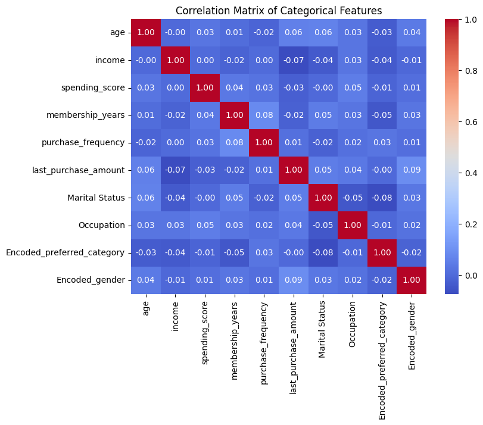

```python
# Plotting the correlation matrix using seaborn
corr = df.corr()
plt.figure(figsize=(8, 6))
sns.heatmap(corr, annot=True, cmap='coolwarm', fmt=".2f")
plt.title('Correlation Matrix of Categorical Features')
plt.show()
```

**Multivariate Analysis**

Income X Gender We believe one of the most important feature to consider when segmenting your customers is their income. Let’s take a look at the relationship between Gender and Income through histograms including the kernel density estimation graph. We draw a plot without Gender segmentation and one with.

```python
#Change the numeric back to categorical to check the imputed values applied
Category_imputed = list(le2.inverse_transform(df.loc[:,'Encoded_preferred_category'].round().astype(int)))
df['Category_Imputed'] = Category_imputed
#df.head(20)
```

```python
Gender_imputed = list(le.inverse_transform(df.loc[:,'Encoded_gender'].round().astype(int)))
df['genderImputed'] = Gender_imputed
#df.head(20)
```

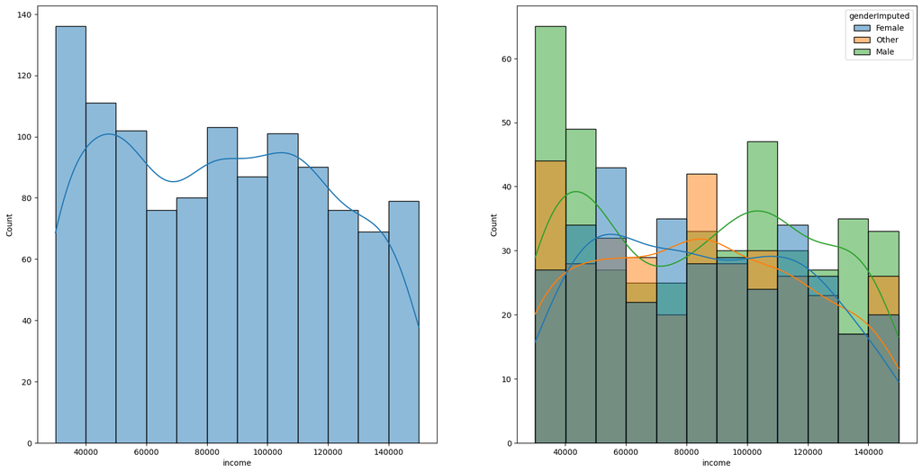

```python
fig, ax = plt.subplots(1, 2, figsize=(20, 10))
sns.histplot(data=df, x='income', kde=True, ax=ax[0])
sns.histplot(data=df, x='income', hue='genderImputed', kde=True, ax=ax[1])
plt.show()
```

Age X Gender - Now, let’s take a look at the distribution of Age and its relation with Gender. Again we draw two histograms, one without Gender segmentation and one with

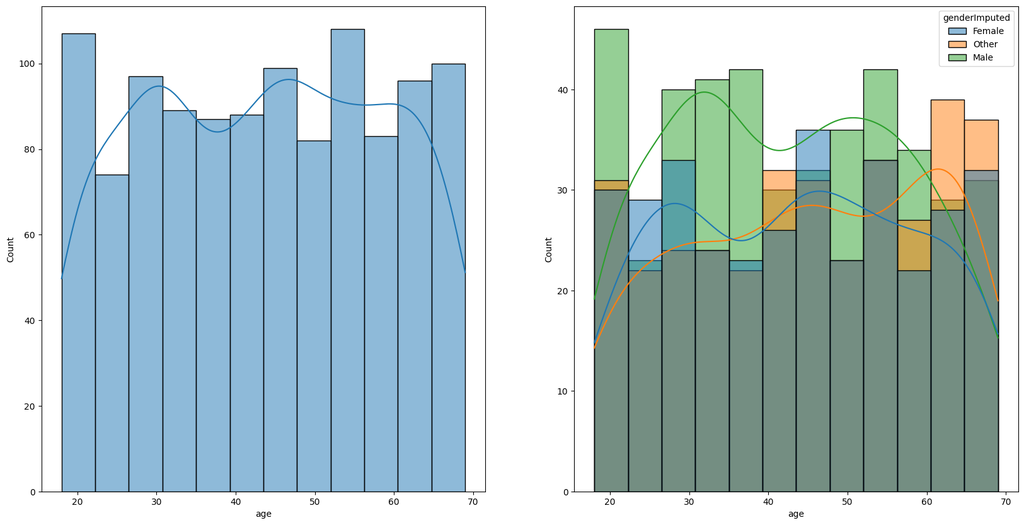

```python
fig, ax = plt.subplots(1, 2, figsize=(20, 10))
sns.histplot(data=df, x='age', kde=True, ax=ax[0])
sns.histplot(data=df, x='age', kde=True, hue='genderImputed', ax=ax[1])
plt.show()
```